# Relatório de Achados Gerais

Mori, Danilo Pereira

9 de setembro de 2018

## Esquema Dos Métodos

### Matriz de Paisagem

1. landsat 8 => recorte de paisagem de 5 km^2 concêntrico ao sítio de amostragem (Site)
2. ajuste de resolução da imagem tal que: densidade de pixels = densidade de indivíduos na área amostrada (DA)  
   ii.a) portanto o lado da célula (l_cel) = 100/sqrt(DA) metros
3. se a porcentagem de cobertura vegetal do pixel for >= 70% então é unidade de habitat; caso contrário é unidade de não habitat
4. a comunidade local é composta de J (número de indivíduos amostrados) unidades de habitat na região central do recorte de paisagem

### Função de Dispersão

1. partimos de uma distribuição de Laplace para simular a função de dispersão
2. determinamos 12 valores de proporção de propágulos que se mantêm até l_cel metros da árvore progenitora (k): 0.99,0.95:0.50,0.25
3. então calculou-se a distância média de dispersão (d) que gerava o correspondente percentil

### Taxa de Especiação - U

Dado matriz de paisagem e riqueza observada (S) no respectivo Site, estimamos um valor médio de taxa de especiação (U) para cada nível de k. Para está estimativa utilizamos um método semi-analítico derivado do modelo neutro de espaço explícito descrito em Rosindell et al. 2008 e estimamos 20 réplicas para cada cenário neutro.

### Equivalência entre grandezas

**i) Parâmetros de dispersão**

Desenvolvemos uma equação que relaciona d com a probabilidade de uma unidade de habitat ser colonizada pela prole de um indivíduo de fora da comunidade local (m) e então calculamos I o número de imigrantes que competem com os indivíduos locais pelas unidades de habitat disponível (Etienne 2005).

Para calcular m a partir do desvio padrão (sd) da função de dispersão, assumimos que as áreas de amostragem são quadradas e distribuição de Laplace:

$$m = sd \frac{1 - e^{-\frac{\sqrt{2} L}{sd}} }{\sqrt{2} L}$$

Onde L = lado da área amostrada.

I se relaciona com m por:

$$I = m (N - 1) / (1 - m)$$

**ii) Parâmetros de Diversidade**

Para cada U calculamos o respectivo theta por:

$$\theta = U (J_M - 1) / (1 - U)$$
Onde $J_M$ é o número de indivíduos na paisagem e é igual ao produto da área do recorte de paisagem em hectares( 500), DA e porcentagem de unidade de habitat na paisagem (p)

### Desenho Experimental

**i) Sítios de amostragem**

80 sítios de amostragem: 1 SAD observada e 1 matriz de paisagem por sítio

**ii) Predições**

*Modelo Neutro Espacialmente Explícito (EE)*

Para cada combinação de parâmetros U e d, a respectiva matriz de paisagem e o modelo descrito por Rosindell et al. (2008) geramos 100 SADs réplicas

*Modelo Neutro Espacialmente Implícito (EI)*

Para cada combinação de parâmetros $\theta$ e I e a formula de amostragem desenvolvida por Etienne (2005) geramos 100 SADs réplicas

**iii) Comparação com o observado**

Cada SAD réplica foi comparada com a respectiva SAD observada no teste de Kolmogorov-Smirnov (KS). O teste KS é um teste estatístico não paramétrico da hipótese nula de que dois vetores de abundância são amostras de uma mesma distribuição teórica. Contabilizamos o número de SADs réplicas em que não foi possível refutar a hipótese nula com alfa crítico de 0.05 na variável (GOF).

## Parâmetros de Dispersão

### d - distância média de dispersão

Perguntas: Quais as situações biológicas que estamos simulando? Em relação às médias de síndromes de dispersão em floresta intacta? E em floresta fragmentada?

#### Gráficos Exploratórios

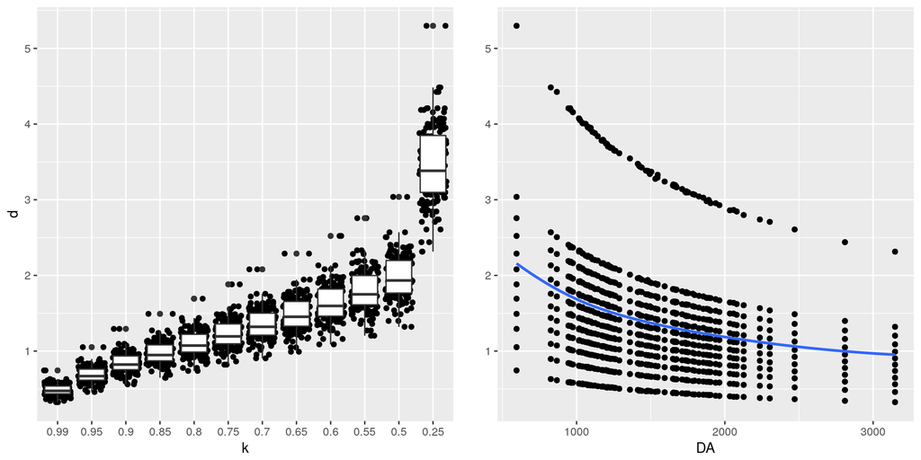

**Figura 1** Distância média de dispersão, k (proporção de propágulos até l_cel metros da planta progenitora) e DA (densidade observada)

#### Tabela de Seleção de Modelos

- distribuição Gamma com função de ligação ‘log’

```
##      dAICc   df
## k+DA     0.0 15
## k      123.6 14
## DA   19032.9 4
## 1    19132.3 3
```

#### Observado e predito

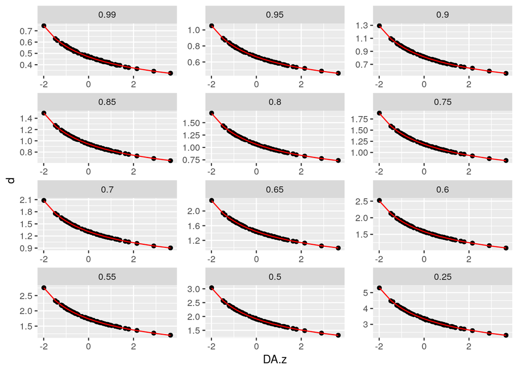

**Figura 2** Distância média de dispersão (d) e o predito segundo d ~ DA.z + k + (1 | Sítio), family=Gamma(log). Os pontos são as distâncias médias estimados para o determinado percentil (k) de propágulos que permanecem até l_cel metros da planta progenitora; em vermelho o predito.

#### Tabela de efeitos na escala padrão

```
##             par.class par.VE  par.value
## DA.z             beta   DA.z  0.8651770
## (Intercept)      alfa k=0.99  0.4800254
## k0.95            alfa k=0.95  2.9486305
## k0.9             alfa  k=0.9  3.6146252
## k0.85            alfa k=0.85  4.1794911
## k0.8             alfa  k=0.8  4.7222410
## k0.75            alfa k=0.75  5.2578802
## k0.7             alfa  k=0.7  5.8093999
## k0.65            alfa k=0.65  6.3961099
## k0.6             alfa  k=0.6  7.0234188
## k0.55            alfa k=0.55  7.7180471
## k0.5             alfa  k=0.5  8.4854431
## k0.25            alfa k=0.25 14.8749015
```

#### Status

Análise da variável quase completa. Problemas de convergência não permitiram estimar os intervalos de confiança das estimativas e nem o R^2 do modelo mais plausível.

**Questões** Qual seria k dado d, ou seja, extrapolar a relação para poder inferir qual seria k para determinadas médias de síndrome de dispersão sem precisar simular as funções de dispersão.

Utilizando a equação matemática estimada seria necessário utilizar k enquanto variável contínua.

### I

Perguntas: Quais são as estimativas do parâmetro de dispersão de EI obtido em campos? Quais são os valores que simulamos?

#### Gráficos Exploratórios

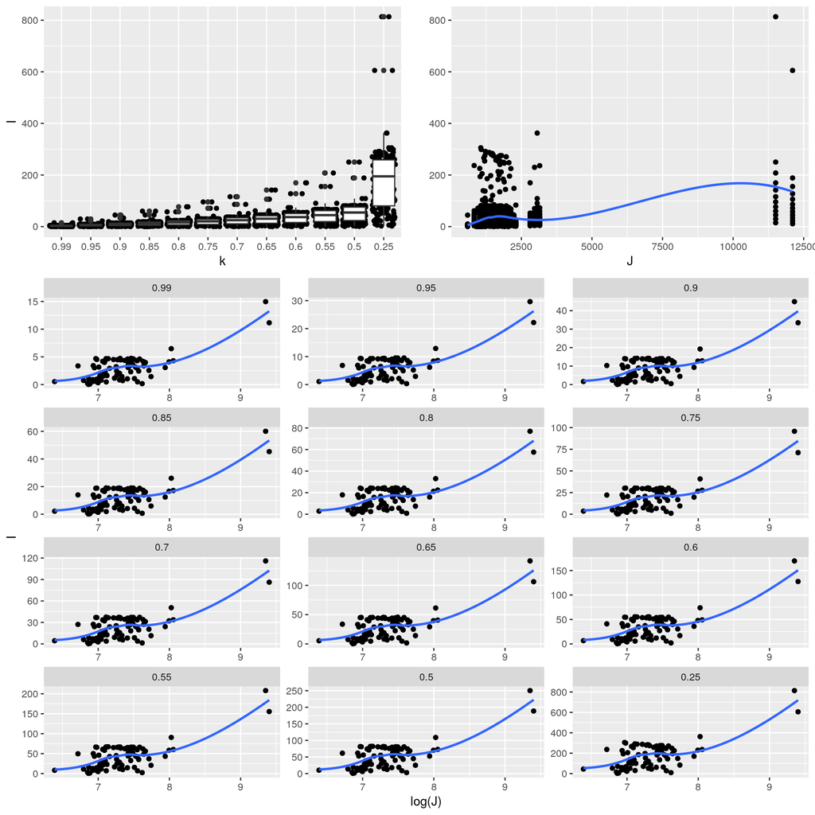

**Figura 1** Gráficos Exploratórios de I, k e J (número de indivíduos amostrado)

#### Status

Não iniciei a análise da variável.

## Parâmetros de Diversidade

### U - taxa de especiação

#### Gráficos Exploratórios

##### Efeitos fixos indivíduais

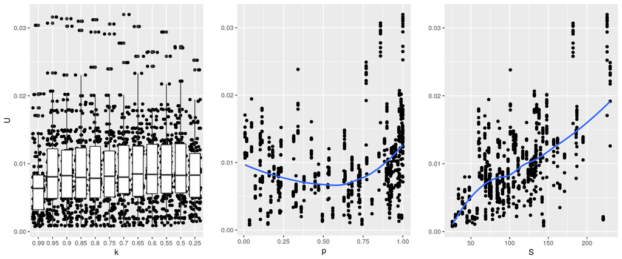

**Figura 1** Taxa de especiação, k, p e S

##### Interações efeitos fixos

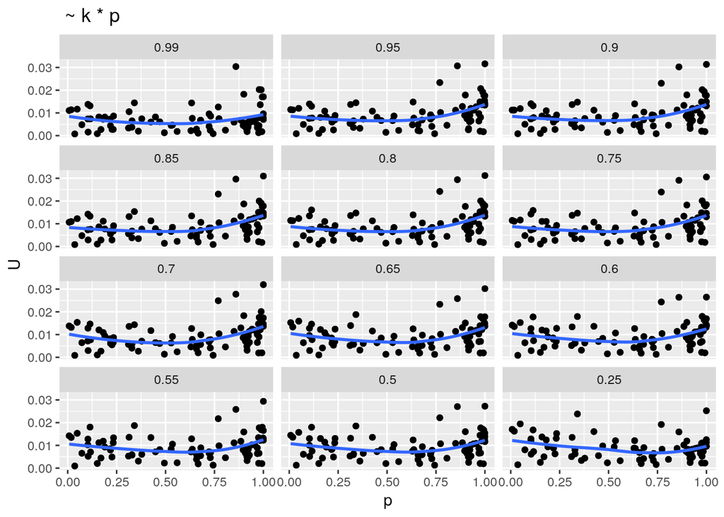

**Figura 2.1** U ~ k * p

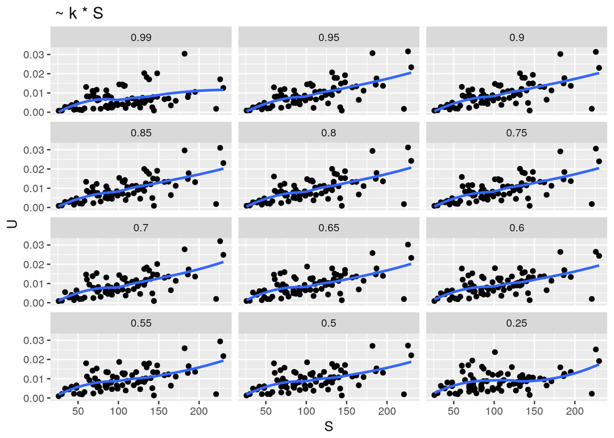

**Figura 2.2** U ~ k * S

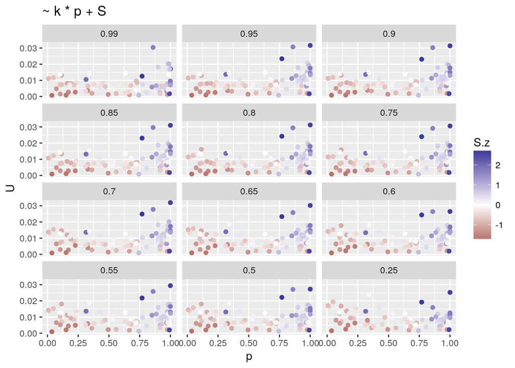

**Figura 2.3** U ~ k * p + S

- Achei estranho que há valores de U baixos para altos valores de S
- Então pensei em um possível efeito do tamanho amostral: quanto maior J maior a árvore genealógica da comunidade [sob hipótese de monodominância] e assim menor a probabilidade média de imigração necessária para gerar uma mesma riqueza observada
- O tamanho da metacomunidade ao redor pode ter o mesmo efeito, esse efeito pode ser expresso em termos de relação de J/J_M pois considera-se a coalescência apenas da área amostral e não da paisagem

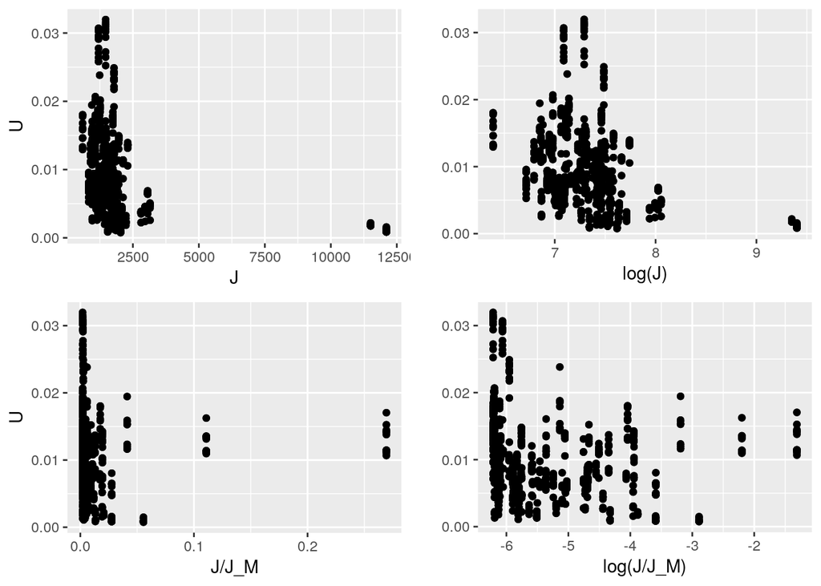

**Figura 2.4** U, J e J/J_M em escala padrão e log

-Parece que há um efeito de log(J), contudo, há correlação entre as variáveis empíricas p, S e J:

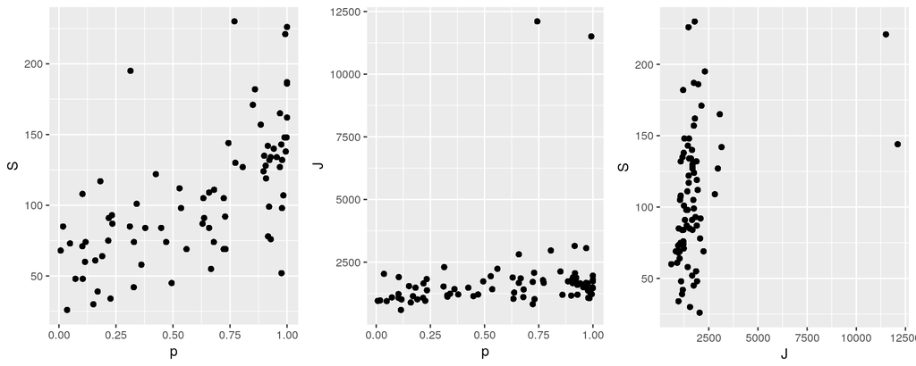

**Figura 2.5** Relação entre co-variáveis empíricas S, J e p

- Na análise de U consideramos o efeito de S, mas não de J. Eu acredito que vale a investigação se os dois outliers de J (J>5000) não podem estar influênciando muito as estimativas

##### Efeitos aleatórios

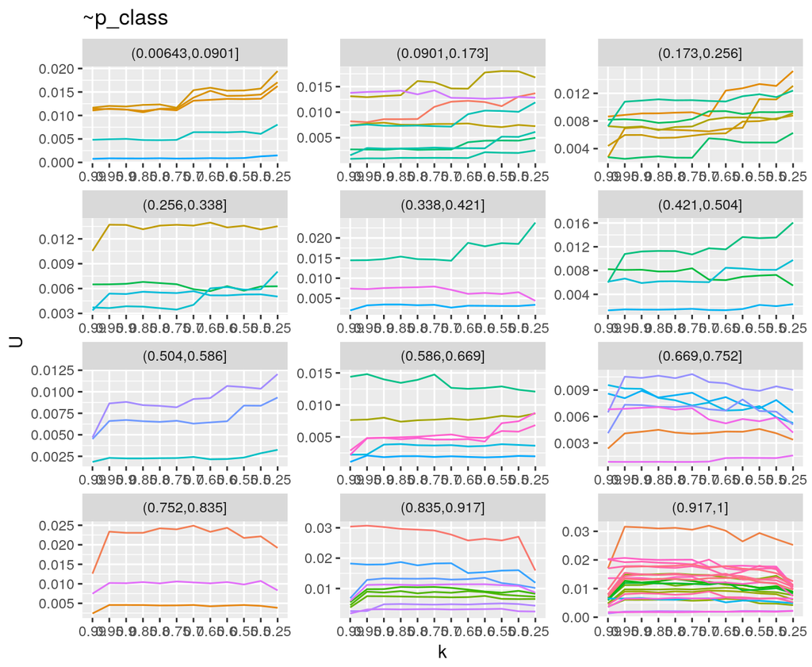

**Figura 3.1** U ~ k * p_class (group=Site)

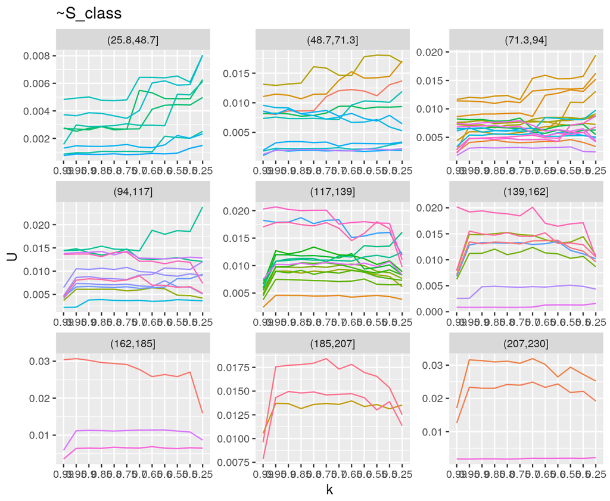

**Figura 3.2** U ~ k * S_class (group=Site)

#### Resultados da dissertação

- Para modelar U aplicamos a transformação logito
- Utilizamos então a distribuição normal e a função de ligação identidade para a seleção dos modelos

##### Tabela de Seleção e R2

*Tabela de Seleção de Variáveis para descrever logito de U*

```
##           dAICc  df weight
## p * k + S    0.0 27 1
## p * k       34.1 26 <0.001
## p + k + S  520.0 16 <0.001
## k + S      524.3 15 <0.001
## k          551.3 14 <0.001
## p + k      554.1 15 <0.001
## p + S      976.8 5  <0.001
## S          981.1 4  <0.001
## 1         1008.1 3  <0.001
## p         1010.9 4  <0.001
```

*R2 marginal e condicional da seleção de modelos*

- pelo método de Nakagawa & Schielzeth (2013)

```
##     p * k + S p + k + S     p + S     k + S         S      p * k     p + k
## R2m 0.4085237 0.3955838 0.3798639 0.3281880 0.3123633 0.05639136 0.0434292
## R2c 0.9659666 0.9525370 0.9362971 0.9522779 0.9359492 0.96602350 0.9526163
##              p         k         1
## R2m 0.02763708 0.0159788 0.0000000
## R2c 0.93640354 0.9520796 0.9356831
```

*Porcentagem da variância explicada pelos efeitos fixos*

- R2m / R2c

```
##  p * k + S  p + k + S      p + S      k + S          S      p * k
## 0.42291700 0.41529497 0.40570880 0.34463469 0.33373955 0.05837473
##      p + k          p          k          1
## 0.04558940 0.02951407 0.01678305 0.00000000
```

##### Predito e Intervalo de Confiança

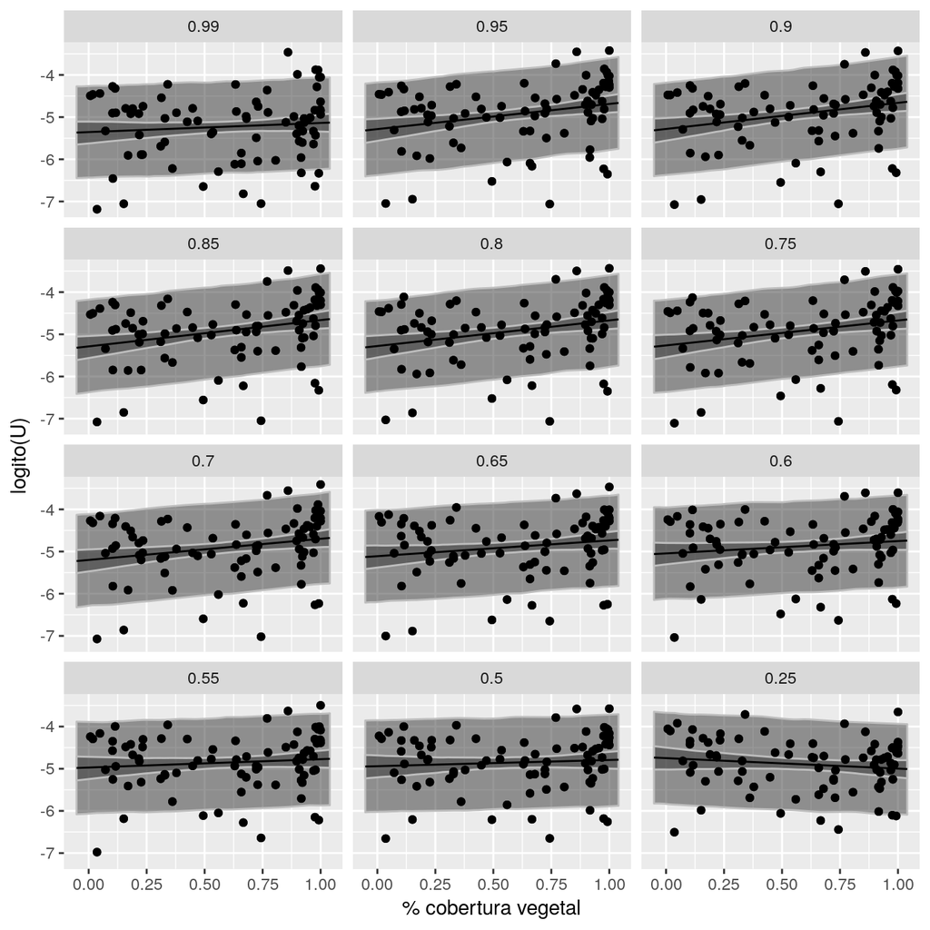

**Figura 1** Logito de U pela porcentagem de cobertura vegetal. A linha é a estimativa da tendência, a região cinza mais escuro corresponde ao intervalo de confiança dos efeitos fixos e a região cinza mais clara o intervalo de confiança considerando todo o modelo.

##### Status

Falta atualizar o método de obtenção do R2m e R2c e recuperar/revisar o texto da dissertação dessa sessão

*Questões*

1. Quando a hipótese de equilíbrio é válida? E quando não for ainda é uma boa aproximação utilizar U como taxa de extinção de espécies raras? O quê é uma espécie rara?